# Data Challenge 4

Pratik Mistry

11/8/2020

**GitHub Link:** https://github.com/pratikmistry96/Data-Science-I-Data-Challenges/tree/master/Data_Challenge_4

# Introduction:

**Assignment:** For Data Challenge #4 we will be using data on National Park visits on tidytuesday (https://github.com/rfordatascience/tidytuesday/tree/master/data/2019/2019-09-17). Please familiarize yourself with the data before you begin. You will be answering the following 3 questions:

1. Make a figure that shows the trend in the raw number of park visitors over time for 3 parks: Crater Lake, Joshua Tree, and Zion. Do the same but for the number of visitors normalized by state population for the state that contains the park.
2. There seems to be a decrease in visitors for both Crater Lake and Zion comparing 1942 to 1941 (less so for Joshua tree). Run a simulation for all three parks (like our restaurant letter grade simulation in class) where you assume the probability of visiting each of the parks in both years (1941 and 1942) are the same. Plot a distribution for the number of people who visited in 1942 from your simulations and compare it to the number of people who actually visited the park in 1942. Remember our rules about iteration! If you do something twice write a function. Use map and apply statements as well. (Hint: You may want to look at the park visits in 1000s – i.e. divide by 1000 to ease the computational burden of your simulation) DON’T FORGET TO SET A SEED FOR REPRODUCIBILITY!
3. Summarize your findings from questions 1 and 2 in a paragraph.

# Load Libraries:

Clear the workspace of any variables and load the appropriate libraries for the analysis

```r
rm(list = ls()) ## Remove any variables in workspace to avoid errors
library(tidyverse) ## Load tidyverse library, which includes dplyr and ggplot2
options(scipen = 999) ## Set this option to avoid scientific notation on y-axis
```

# Load Data:

Load national park data from tidytuesday github repository

```r
## Load national park data and store it into a variable: parks
parks <- read_csv("https://raw.githubusercontent.com/rfordatascience/tidytuesday/master/data/2019/2019-09-17/national_parks.csv")

## Load state population data and store it into a a variable: state_pop
state_pop <- read_csv("https://raw.githubusercontent.com/rfordatascience/tidytuesday/master/data/2019/2019-09-17/state_pop.csv")
```

# Data Wrangling:

The following prepares the data to complete the tasks presented in the data challenge to restrict the data to Joshua Tree, Crater Lake, and Zion

```r
parks <- parks %>%
  filter(parkname %in% c("Joshua Tree", ## Filter the data to restrict it to 3 national parks
                         "Crater Lake",
                         "Zion"),
         year != "Total") %>% ## Remove "Total" from the years
  mutate(year = as.numeric(year)) %>% ## Convert year from characters to numeric
  inner_join(state_pop,by = c("year","state")) %>% ## Add the state population by year and state
  mutate(norm_visitors = visitors/pop) ## Normalize visitors by state population
```

# Create Functions:

This section defines the functions that will be used in further analyzes

**Function 1:** This function is created to plot the number of visitors over the years and color the data by park name. There is an input to specify is the function will plot visitors normalized by state population at that year

```r
plt_visitors <- function(data, normalize) { ## Create a function called "plt_visitors" with inputs data and logical
                                            ## value for plot normalization
  if(normalize){ ## Use an if statement to see if we're plotting the visitors normalized by population
    plt_obj <- data %>% ## Store the plot object in a variable titled 'plt_obj'
      ggplot(aes(x = year, ## Make the x-axis year
                 y = norm_visitors, ## Make the y-axis the visitors normalized by population
                 group = parkname)) + ## Group by park names
      labs(
        y = "Park Visitors Normalized by State Population" ## Add y-label
      )
  }else{ ## The else will create an object for non-normalized data
    plt_obj <- data %>%
      ggplot(aes(x = year,## x-axis is the year
                 y = visitors, ## make the y-axis the raw number of visitors
                 group = parkname)) +
      labs(
        y = "Park Visitors"
      )
  }
  plt_obj <- plt_obj + ## Add common properties to the plot object
    geom_line(aes(col = parkname), ## Color the lines by park name
              lwd = 1) + ## Adjust line width
    labs(
      title = "Park Visitors Over the Years", ## Title the graph
      x = "Year", ## Label the x axis
      col = "Park Names" ## Title the legend
    )
  return(plt_obj) ## Return the plot
}
```

**Function 2:** This function is created to simulate the number of visitors using observed values from two years. This function will be used to see how far the observed value of visitors deviated from the simulated values in the year 1942.

```r
## Create a function called 'sim_visitors' with inputs: data, park(name), and reps(repetition)
sim_visitors <- function(data, park, reps){
  data_sub <- data %>% ## Create a variable called data_sub to subset the data frame
    filter(parkname == park) ## Filter the data by the input specified park name
  visitors_1941 <- data_sub$visitors[data_sub$year == 1941] ## Extract the number of visitors from year 1941
  visitors_1942 <- data_sub$visitors[data_sub$year == 1942] ## Extract the number of visitors from year 1942
  total_visitors <- visitors_1941 + visitors_1942 ## Add the number of visitors from 1941 and 1942
  ## Run a simulation and store it in a data frame using a probability of 0.5
  visitors_sim <- data.frame(dist = rbinom(reps,
                                           total_visitors,
                                           p = 0.5))
  ## Plot the distribution of the simulation
  visitors_sim %>%
    ggplot(aes(dist)) + ## Use the above calculated simulation as the input
    geom_histogram(binwidth = 10, ## Create a histogram with a bindwidth of 20
                   fill = "blue") +
    geom_vline(xintercept = visitors_1942, ## Add an x-intercept of the observed values of visitors in 1942
               col = "red",
               lwd = 1) +
    annotate("text", ## use annotate to add an annotation for the observed number of visitors
             x = visitors_1942 + 150,
             y = 10,
             label = "observed",
             hjust = "left",
             angle = 0) +
    labs(
      title = paste0("Simulated Distribution of Visitors in 1942", ## Add the title
                     " - ", park),
      x = "Number of Visitors - if p = 0.50", ## Add x label
      y = "Count" ## Add the y label
    )
}
```

# Task 1: Trend Plot of Visitors

**Plot 1:**

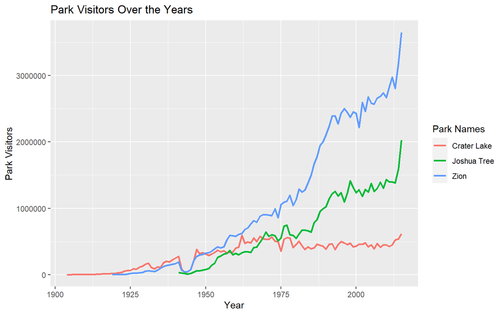

```r
plt_visitors(parks, FALSE) ## Plot visitor information over the years by park
```

**Figure 1:** A plot of raw number of visitors by year of three national parks: Crater Lake, Joshua Tree, and Zion. Notice that there is a dip in the number of visitors between 1935 and 1955

**Plot 2:**

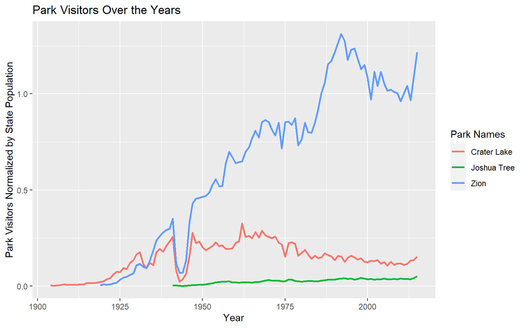

```r
plt_visitors(parks, TRUE) ## Plot normalized visitor information
```

**Figure 2:** A plot of number of visitors normalized by the state population by year of three national parks: Crater Lake, Joshua Tree, and Zion. If we divide by the states population, the dip in visitors is still there, which indicates that the dip is not due to a decrease in the state’s population between 1935 and 1955.

**Plot 3:**

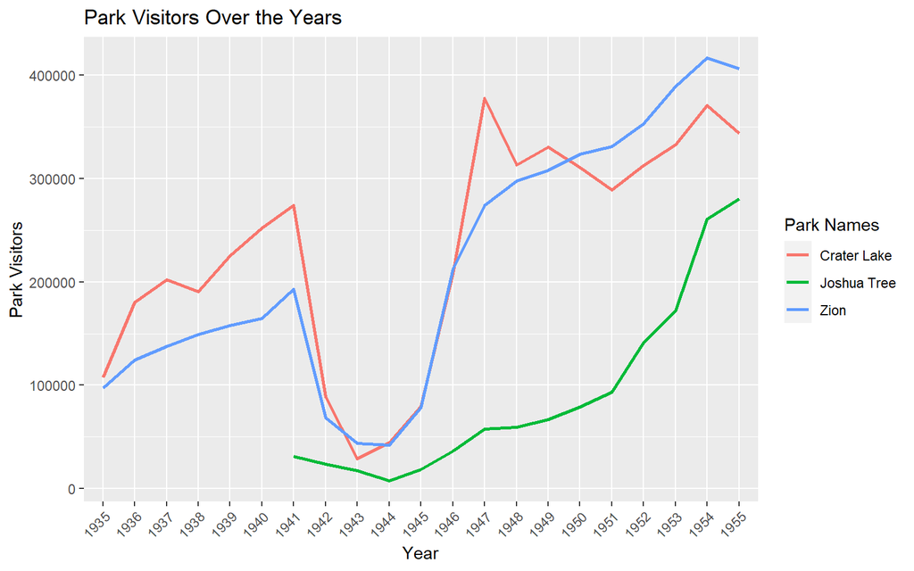

```r
parks %>%
  filter(year %in% 1935:1955) %>% ## Filter the data and restrict the years between 1935 and 1955
  mutate(year = factor(year)) %>% ## Turn the year values into factors
  plt_visitors(FALSE) + ## Use the plot function with the normalization = FALSE
  theme(
    axis.text.x = element_text(angle = 45, ## Adjust the text angle to 45
                               hjust = 1) ## Align the text
  )
```

**Figure 3:** Based on the previous two figures, I am creating a new plot to see which years the dip in visitors occurred.

# Task 2:

```r
set.seed(96) ## Set the seed to ensure randomization is always the same
## Create a list of park names to use as input for map function
park_names <- list("Joshua Tree",
                "Crater Lake",
                "Zion")
## Use a map function to simulate visitors for all three parks
visitor_simulation <- map(park_names,
                          sim_visitors,
                          data = parks,
                          reps = 1000) ## Iterate the data 1000 times
```

**Park Name:** Joshua Tree

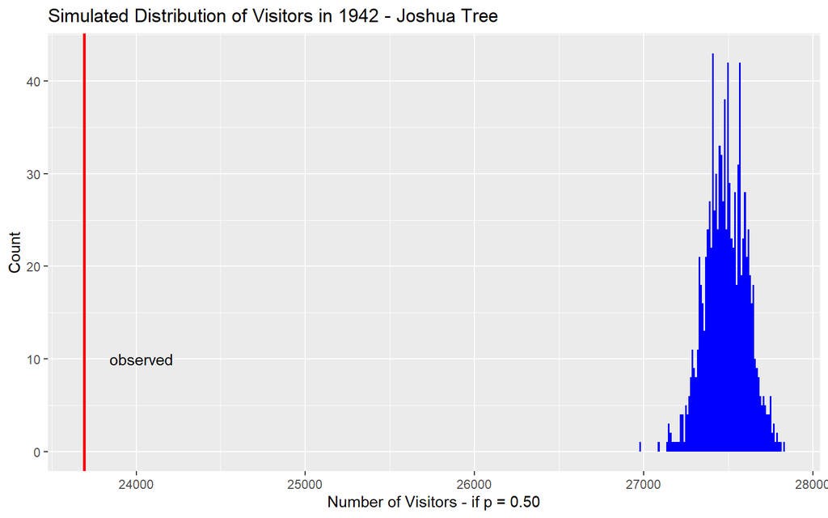

```r
visitor_simulation[[1]] ## Plot the Joshua Tree distribution
```

**Figure 4:** Simulated distribution of visitors in 1942 with a red line indicating the actual observed value of visitors in 1942 for the national park - Joshua Tree. Notice that the difference between the two values in approximately 4000 people, which is not as high as compared to the other national parks.

**Park Name:** Crater Lake

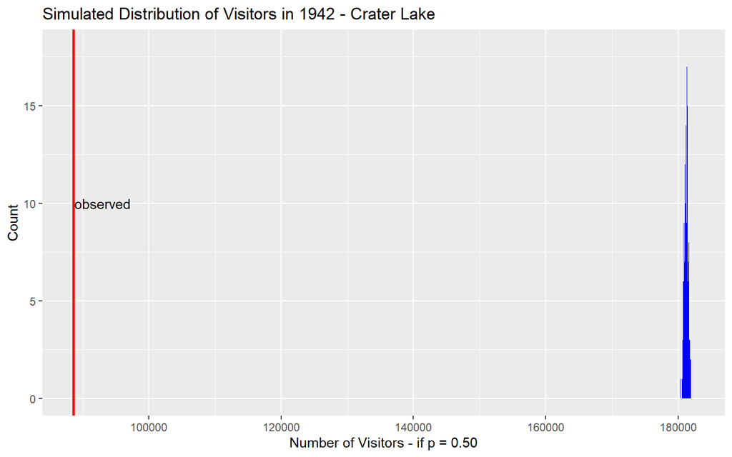

```r
visitor_simulation[[2]] ## Plot the crater Lake distribution
```

**Park Name:** Zion

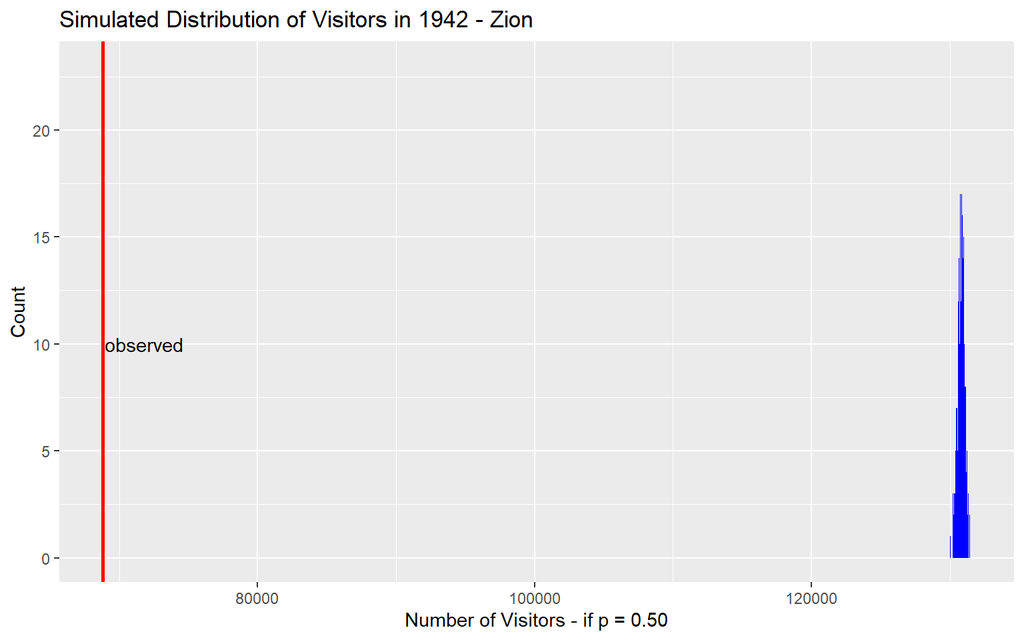

```r
visitor_simulation[[3]] ## plot the zion distribution
```

# Results: